# 黒部ダム観測値の修正に伴う図表変更

```r
library(package="TateyamaForest")
library(kableExtra)
library(ggplot2)
library(patchwork)
#help(package="TateyamaForest")
#data(package="TateyamaForest")
```

# 黒部ダム月平均気温

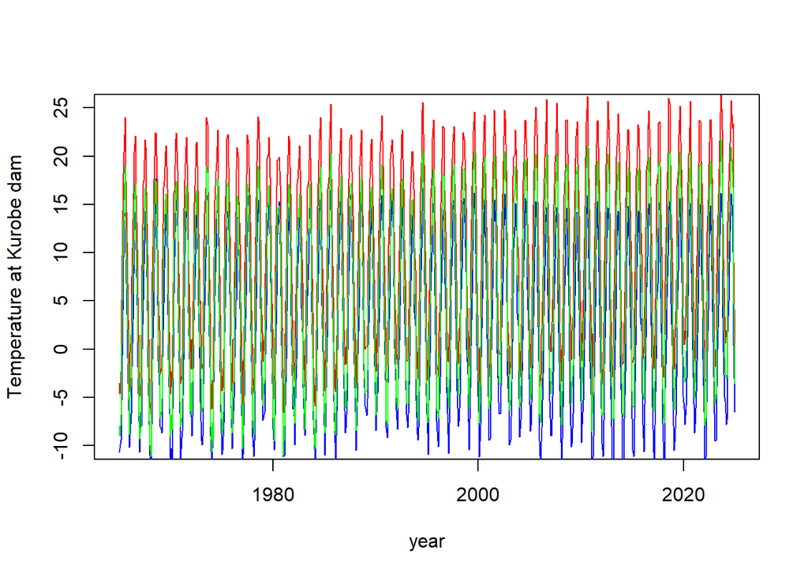

```r
#Fig_year_WI_3()
dd<-kurobe_1965_2024
dd_plot<-function(dd=dd){
  plot(dd$date,dd$max,type="l",col="red",ylim=c(-10,25),
       xlab="year",ylab="Temperature at Kurobe dam")
  lines(dd$date,dd$min,col="blue")
  lines(dd$date,dd$mean,col="green")
}
dd_plot(dd)
```

```r
(.<-kurobe_dam_temperature)
```

|  | year | min | max | mean |
| --- | --- | --- | --- | --- |
| 1 | 1965 | 1.016667 | 8.850000 | 4.133333 |
| 2 | 1966 | 1.300000 | 8.825000 | 4.116667 |
| 3 | 1967 | 1.850000 | 8.925000 | 4.225000 |
| 4 | 1968 | 1.800000 | 8.966667 | 4.258333 |
| 5 | 1969 | 1.733333 | 9.225000 | 4.491667 |
| 6 | 1970 | 1.725000 | 8.858333 | 4.141667 |
| 7 | 1971 | 1.941667 | 8.741667 | 4.041667 |
| 8 | 1972 | 2.758333 | 10.316667 | 5.575000 |
| 9 | 1973 | 1.941667 | 9.300000 | 4.566667 |
| 10 | 1974 | 1.858333 | 8.491667 | 3.791667 |

[output cut: 50 more lines]

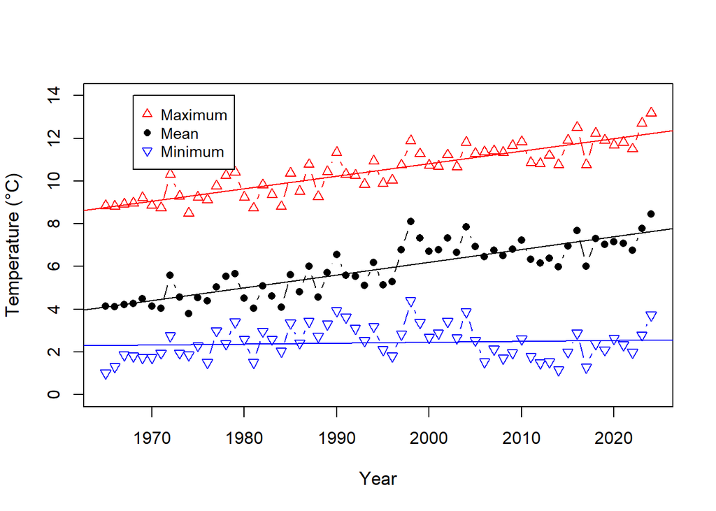

```
## [[1]]
##
## Call:
## lm(formula = d$max ~ d$year)
##
## Residuals:
##     Min      1Q  Median      3Q     Max
## -1.0767 -0.3899  0.0286  0.3190  1.1700
##
## Coefficients:
##               Estimate Std. Error t value Pr(>|t|)
## (Intercept) -1.063e+02  8.383e+00  -12.68   <2e-16 ***
## d$year       5.856e-02  4.203e-03   13.93   <2e-16 ***
## ---
## Signif. codes:  0 '***' 0.001 '**' 0.01 '*' 0.05 '.' 0.1 ' ' 1
##
## Residual standard error: 0.5638 on 58 degrees of freedom
## Multiple R-squared:   0.77,  Adjusted R-squared:  0.766
## F-statistic: 194.2 on 1 and 58 DF,  p-value: < 2.2e-16
##
##
## [[2]]
##
## Call:
## lm(formula = d$min ~ d$year)
##
## Residuals:
##     Min      1Q  Median      3Q     Max
## -1.3582 -0.5608  0.0178  0.4616  1.9382
##
## Coefficients:
##              Estimate Std. Error t value Pr(>|t|)
## (Intercept) -6.451620  11.481505  -0.562    0.576
## d$year       0.004457   0.005756   0.774    0.442
##
## Residual standard error: 0.7722 on 58 degrees of freedom
## Multiple R-squared:  0.01023,    Adjusted R-squared:  -0.006834
## F-statistic: 0.5995 on 1 and 58 DF,  p-value: 0.4419
##
##
## [[3]]
##
## Call:
## lm(formula = d$mean ~ d$year)
##
## Residuals:
##      Min       1Q   Median       3Q      Max
## -1.20201 -0.50543 -0.03395  0.42893  2.01856
##
## Coefficients:
##               Estimate Std. Error t value Pr(>|t|)
## (Intercept) -1.135e+02  9.982e+00  -11.37   <2e-16 ***
## d$year       5.985e-02  5.005e-03   11.96   <2e-16 ***
## ---
## Signif. codes:  0 '***' 0.001 '**' 0.01 '*' 0.05 '.' 0.1 ' ' 1
##
## Residual standard error: 0.6714 on 58 degrees of freedom
## Multiple R-squared:  0.7115, Adjusted R-squared:  0.7065
## F-statistic:   143 on 1 and 58 DF,  p-value: < 2.2e-16
```

```r
Fig_kurobe_dam_temperature()
```

```r
# y1<-1965; y2<-2024
# dt1965_2024<-.$mean[.$year==y2]-.$mean[.$year==y1]
# paste("黒部ダム月平均気温は1965-2024間に", (dt1965_2024)/(y2-y1)*10,"℃/10年上昇た")
#
# y1<-1965; y2<-2004
# dt1965_2004<-.$mean[.$year==y2]-.$mean[.$year==y1]
# paste("黒部ダム月平均気温は1965-2004間に", (dt1965_2024)/(y2-y1)*10,"℃/10年上昇た")
```

# Fig_year_WI_3()

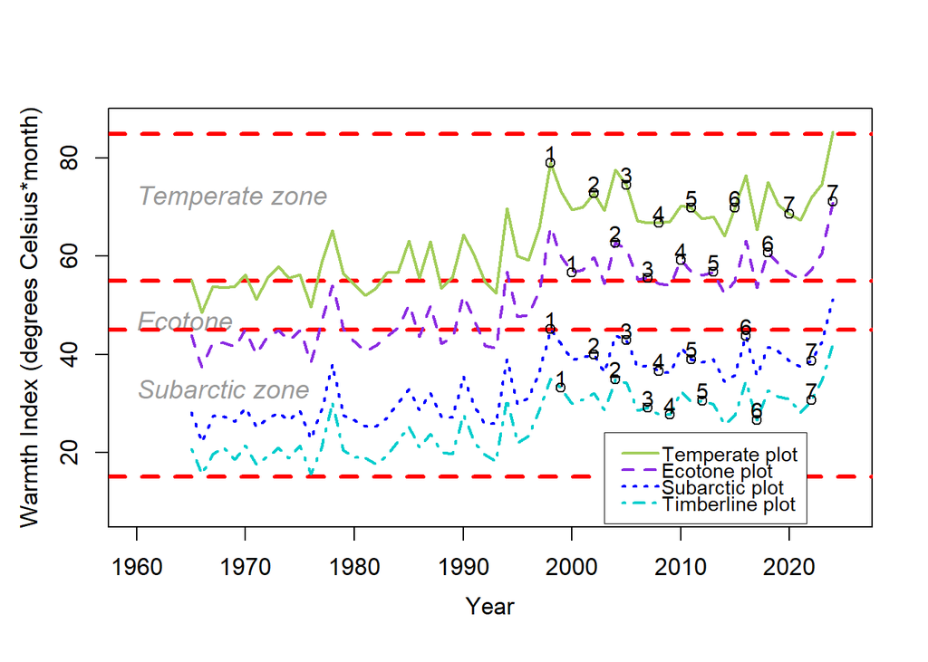

```r
TateyamaForest::Fig_year_WI_3()
```

WI_with_KurodeDamObservation の修正が必要 ok plt5 -> plt6 ok

## 温量指数のMann-Kendall検定と傾き

```r
data(wi_year)
  d<-c()
for (i in plt6$na){
  yr=wi_year$year
  d<-c(d,list(MannKendall_lm(yr,wi_year[,i])))
}
names(d)<-plt6$na
d
```

```
## $Bunazaka
## $Bunazaka$MannKendall
## tau = 0.59, 2-sided pvalue =< 2.22e-16
##
## $Bunazaka$lm_fit
##
## Call:
## lm(formula = v ~ yr)
##
## Residuals:
##      Min       1Q   Median       3Q      Max
## -10.3141  -3.2789  -0.3336   2.7609  14.2957
##
## Coefficients:
##               Estimate Std. Error t value Pr(>|t|)
## (Intercept) -730.55894   75.03980  -9.736 8.30e-14 ***
## yr             0.39803    0.03762  10.580 3.69e-15 ***
## ---
## Signif. codes:  0 '***' 0.001 '**' 0.01 '*' 0.05 '.' 0.1 ' ' 1
##
## Residual standard error: 5.047 on 58 degrees of freedom
## Multiple R-squared:  0.6587, Adjusted R-squared:  0.6528
## F-statistic: 111.9 on 1 and 58 DF,  p-value: 3.688e-15
##
##
##
## $Kaminokodaira
## $Kaminokodaira$MannKendall
## tau = 0.574, 2-sided pvalue =< 2.22e-16
##
## $Kaminokodaira$lm_fit
##
## Call:
## lm(formula = v ~ yr)
##
## Residuals:
##    Min     1Q Median     3Q    Max
## -9.203 -3.444 -0.087  2.565 13.720
##
## Coefficients:
```

[output cut: 46 more lines]

```
##
## Residuals:
##    Min     1Q Median     3Q    Max
## -7.141 -2.643 -0.220  2.519  9.106
##
## Coefficients:
##               Estimate Std. Error t value Pr(>|t|)
## (Intercept) -525.78008   55.61667  -9.454 2.39e-13 ***
## yr             0.27650    0.02788   9.916 4.24e-14 ***
## ---
## Signif. codes:  0 '***' 0.001 '**' 0.01 '*' 0.05 '.' 0.1 ' ' 1
##
## Residual standard error: 3.741 on 58 degrees of freedom
## Multiple R-squared:  0.629,  Adjusted R-squared:  0.6226
## F-statistic: 98.33 on 1 and 58 DF,  p-value: 4.237e-14
```

### 温暖化と森林帯

```r
d<-subset(wi_year,year>1993)
yr.<-d$yr.
wi.<-d$Kaminokodaira
ratio_wi55up<-100*sum(wi.>55)/length(wi.)
 paste0("Ecotone plot crossed the ecotone–temperate boundary (WI = 55 °C·month) for the first time in 1994. In the period 2013–2024, ",round(ratio_wi55up,1),",% of years exceeded WI = 55")
```

[output not shown]

# オブジェクト生成

```r
  # オブジェクト生成
  s <- new_statistics(
    wi_year          = wi_year,
    Abies_death_ratio = Abies_death_ratio,
    f1_raw           = .data_Fig_yr_ba_kaminokodaira_Cryptomeria_Fagus_Abies_2024,
    f2_raw           = .data_Fig_yr_ba_kaminokodaira_zone_2024
  )

  print(s)
```

```
## $wi
##      year Bunazaka Kaminokodaira Matsuotoge Kagamiishi
## 1965 1965   55.174        43.954     28.145     20.696
## 1966 1966   48.574        37.354     22.145     15.596
## 1967 1967   53.803        42.295     27.445     19.745
## 1968 1968   53.574        42.354     27.245     20.896
## 1969 1969   53.903        41.554     26.245     18.545
## 1970 1970   56.274        45.054     29.145     21.445
## 1971 1971   51.203        40.095     25.245     17.596
## 1972 1972   55.503        43.554     26.845     19.145
## 1973 1973   57.903        44.813     28.145     20.996
## 1974 1974   55.503        42.854     26.545     18.845
## 1975 1975   56.303        44.854     28.445     21.396
## 1976 1976   49.674        38.454     22.845     15.596
## 1977 1977   58.903        46.854     29.034     21.296
```

[output cut: 132 more lines]

## Pearson相関: WI vs. BA比

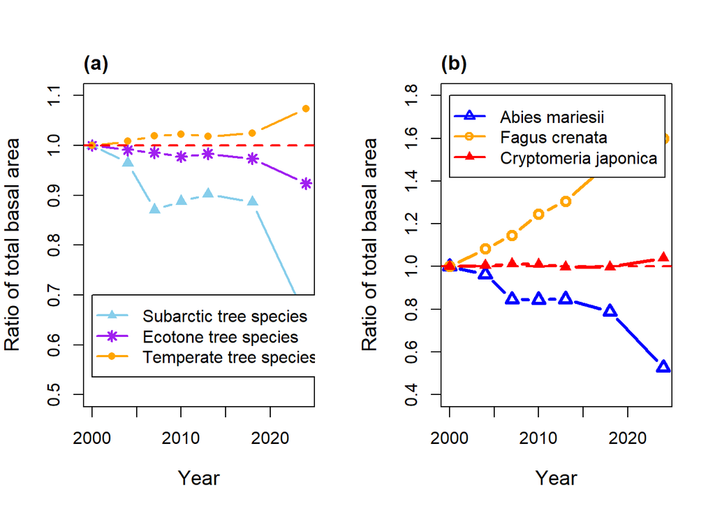

```r
Fig_yr_ba_Kaminoko_JVS2()
```

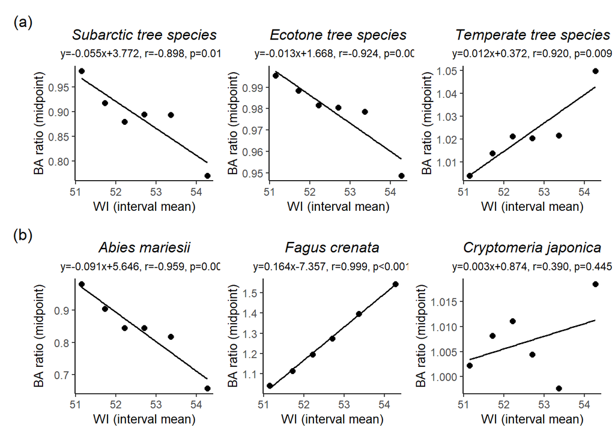

```r
# Fig_yr_ba_Kaminoko_JVS2()
# res3 <- statistics_cor_wi_ba_EcotonePlot(s)

res<-Fig_wi_ba_cor_ancova_JVS2()
```

```r
res
```

```
## $slopes
##                             label                     sp        slope
## Ecotone tree species      By zone   Ecotone tree species -0.013111171
## Subarctic tree species    By zone Subarctic tree species -0.054821567
## Temperate tree species    By zone Temperate tree species  0.012366232
## Abies mariesii         By species         Abies mariesii -0.091383635
## Cryptomeria japonica   By species   Cryptomeria japonica  0.002532322
## Fagus crenata          By species          Fagus crenata  0.163935437
##
## $pairwise
##                                         comparison slope_ref slope_other
## 1   Ecotone tree species vs Subarctic tree species  -0.01311    -0.05482
## 2   Ecotone tree species vs Temperate tree species  -0.01311     0.01237
## 3 Subarctic tree species vs Temperate tree species  -0.05482     0.01237
## 4           Abies mariesii vs Cryptomeria japonica  -0.09138     0.00253
## 5                  Abies mariesii vs Fagus crenata  -0.09138     0.16394
## 6            Cryptomeria japonica vs Fagus crenata   0.00253     0.16394
##   slope_diff t_value p_value      label
## 1   -0.04171  -3.668  0.0032    By zone
## 2    0.02548   2.240  0.0448    By zone
## 3    0.06719   5.908  0.0001    By zone
## 4    0.09392   8.012  0.0000 By species
## 5    0.25532  21.781  0.0000 By species
## 6    0.16140  13.769  0.0000 By species
```

```r
# d<-TemperatureWIAbiesPopulation
# wi.<-subset(d,plot=="Kaminokodaira")$WI
# par(mfrow = c(2, 3))
#
# d2<-.data_Fig_yr_ba_kaminokodaira_zone_2024
# ba_wi_plot3(wi.,d2)
#
# d2<-.data_Fig_yr_ba_kaminokodaira_Cryptomeria_Fagus_Abies_2024
# ba_wi_plot3(wi.,d2)
# Fig_wi_ba_cor_JVS2()
```

## ANCOVA: BA比 ~ WI * 樹種/zone

```r
res4 <- statistics_ANCOVA_wi_ba_EcotonePlot(s)
```

```
## ANCOVA: BA ratio ~ WI * species/zone
```

```
##
## --- By species ---
##
## Call:
## lm(formula = ba_ratio ~ WI * sp, data = data)
##
## Residuals:
##       Min        1Q    Median        3Q       Max
## -0.246180 -0.034798 -0.000692  0.013628  0.212398
##
## Coefficients:
##                            Estimate Std. Error t value Pr(>|t|)
## (Intercept)               -0.377254   0.550343  -0.685  0.50349
## WI                         0.027217   0.009083   2.996  0.00904 **
## spCryptomeria japonica     1.253730   0.778302   1.611  0.12805
## spAbies mariesii           2.530257   0.778302   3.251  0.00537 **
## WI:spCryptomeria japonica -0.025024   0.012845  -1.948  0.07036 .
## WI:spAbies mariesii       -0.049113   0.012845  -3.823  0.00166 **
## ---
## Signif. codes:  0 '***' 0.001 '**' 0.01 '*' 0.05 '.' 0.1 ' ' 1
##
## Residual standard error: 0.119 on 15 degrees of freedom
## Multiple R-squared:  0.8058, Adjusted R-squared:  0.7411
## F-statistic: 12.45 on 5 and 15 DF,  p-value: 6.729e-05
##
## --- Slope of each group ---
##   Fagus crenata                0.02722 /WI
##   Cryptomeria japonica         0.00219 /WI
##   Abies mariesii               -0.02190 /WI
##
## --- Pairwise slope comparisons (ba_ratio ~ WI) ---
##                               comparison slope_ref slope_other slope_diff
## 1  Fagus crenata vs Cryptomeria japonica   0.02722     0.00219   -0.02502
## 2        Fagus crenata vs Abies mariesii   0.02722    -0.02190   -0.04911
## 3 Cryptomeria japonica vs Abies mariesii   0.00219    -0.02190   -0.02409
##   t_value p_value
## 1  -1.948  0.0704
## 2  -3.823  0.0017
## 3  -1.875  0.0804
##
```

[output cut: 23 more lines]

```
##
## --- Slope of each group ---
##   Temperate tree species       0.00371 /WI
##   Ecotone tree species         -0.00402 /WI
##   Subarctic tree species       -0.01579 /WI
##
## --- Pairwise slope comparisons (ba_ratio ~ WI) ---
##                                         comparison slope_ref slope_other
## 1   Temperate tree species vs Ecotone tree species   0.00371    -0.00402
## 2 Temperate tree species vs Subarctic tree species   0.00371    -0.01579
## 3   Ecotone tree species vs Subarctic tree species  -0.00402    -0.01579
##   slope_diff t_value p_value
## 1   -0.00773  -1.548  0.1425
## 2   -0.01950  -3.904  0.0014
## 3   -0.01177  -2.357  0.0325
```

```r
res4$by_species$slopes
```

```
##        Fagus crenata Cryptomeria japonica       Abies mariesii
##          0.027216737          0.002192524         -0.021896449
```

## Pearson相関: WI vs. 累積死亡率

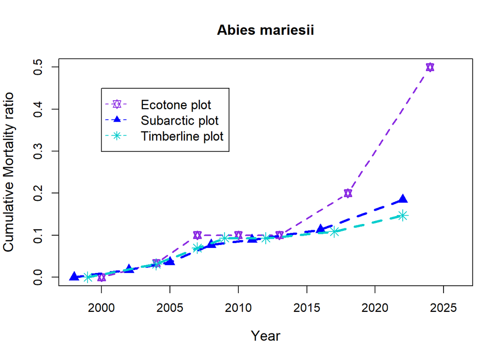

```r
Fig_Abies_death_ratio()
```

```r
res1 <- statistics_cor_WI_AbiesCumulativeMortality(s)
```

```
## Pearson correlation: WI vs. cumulative mortality
```

```r
res1
```

| plot | r | p | n |
| --- | --- | --- | --- |
| Kaminokodaira | 0.8446427 | 0.01677438 | 7 |
| Matsuotoge | -0.4304284 | 0.33504659 | 7 |
| Kagamiishi | -0.6352663 | 0.12525620 | 7 |
| Pooled | 0.4086731 | 0.06586100 | 21 |

## ANCOVA: 累積死亡率 ~ year * plot

```r
res2 <- statistics_ANCOVA_Abies_CumulativeDeathRatio_year_plot(s)
```

```
## ANCOVA: cumulative mortality ~ year * plot
```

```
##
## Call:
## lm(formula = death_ratio ~ year * plot, data = s$death_data)
##
## Residuals:
##      Min       1Q   Median       3Q      Max
## -0.08700 -0.01029 -0.00093  0.01097  0.11083
##
## Coefficients:
##                       Estimate Std. Error t value Pr(>|t|)
## (Intercept)         -36.809434   4.595067  -8.011 8.47e-07 ***
## year                  0.018379   0.002285   8.043 8.06e-07 ***
## plotMatsuotoge       21.662900   6.495176   3.335  0.00452 **
## plotKagamiishi       24.601622   6.694107   3.675  0.00225 **
## year:plotMatsuotoge  -0.010802   0.003232  -3.343  0.00445 **
## year:plotKagamiishi  -0.012267   0.003330  -3.684  0.00221 **
## ---
## Signif. codes:  0 '***' 0.001 '**' 0.01 '*' 0.05 '.' 0.1 ' ' 1
##
## Residual standard error: 0.04621 on 15 degrees of freedom
## Multiple R-squared:  0.8616, Adjusted R-squared:  0.8154
## F-statistic: 18.67 on 5 and 15 DF,  p-value: 5.798e-06
##
##
## --- Slope of each plot ---
##   Kaminokodaira        0.018379 /yr
##   Matsuotoge           0.007577 /yr
##   Kagamiishi           0.006112 /yr
##
## --- Pairwise slope comparisons (death_ratio ~ year) ---
##                    comparison slope_ref slope_other slope_diff t_value p_value
## 1 Kaminokodaira vs Matsuotoge   0.01838     0.00758   -0.01080  -3.343  0.0045
## 2 Kaminokodaira vs Kagamiishi   0.01838     0.00611   -0.01227  -3.684  0.0022
## 3    Matsuotoge vs Kagamiishi   0.00758     0.00611   -0.00146  -0.440  0.6663
```

```r
res2$pairwise
```

| comparison | slope_ref | slope_other | slope_diff | t_value | p_value |
| --- | --- | --- | --- | --- | --- |
| Kaminokodaira vs Matsuotoge | 0.01838 | 0.00758 | -0.01080 | -3.343 | 0.0045 |
| Kaminokodaira vs Kagamiishi | 0.01838 | 0.00611 | -0.01227 | -3.684 | 0.0022 |
| Matsuotoge vs Kagamiishi | 0.00758 | 0.00611 | -0.00146 | -0.440 | 0.6663 |

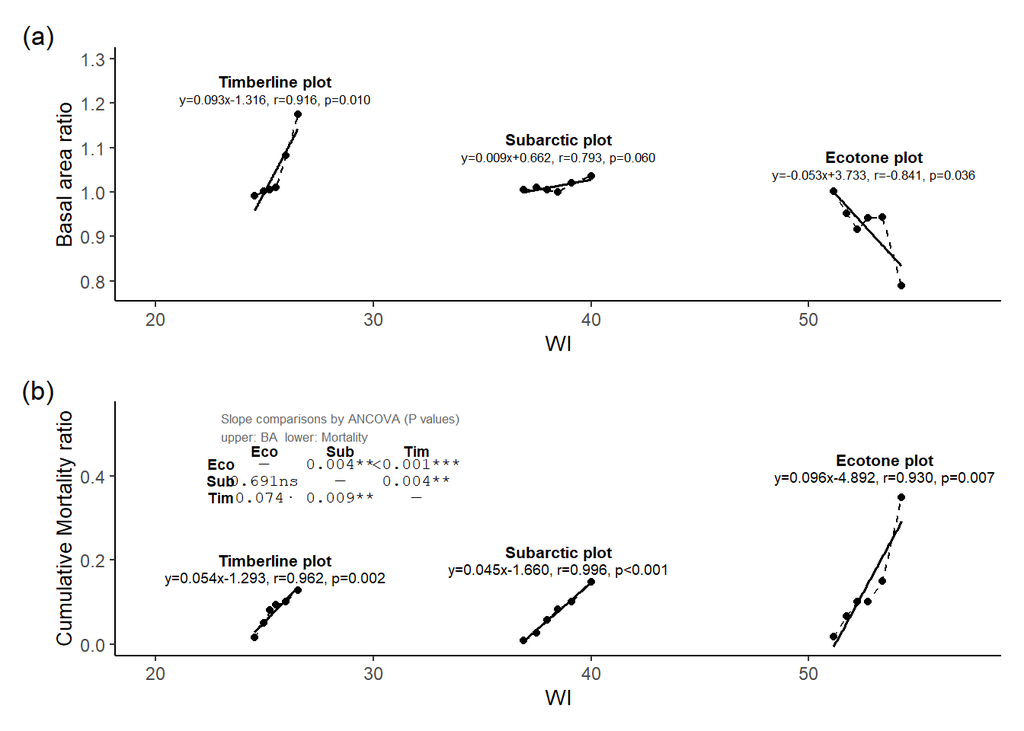

```r
Fig_Abies_wi_ba_mortality()
```

先のEcoto plotにおけるオオシラビソのBa ratioはプロット全体のtotal BAに対しての変化(Fig_wi_ba_cor_ancova_JVS2)，この図のBa ratioはオオシラビソに限ったBAの変化(BAi/BA1)，回帰パラメーターが若干異なる

# Appendix

## 気温因子(Tmax,Tmin,Tmean,WI)とオオシラビソ個体群動態(Condit G,M,I)との相関

```r
TemperatureWIAbiesPopulation
```

| plot | period | yr1 | yr2 | Tmin | Tmax | Tmean | WI | n0 | n1 | nS | t | p | m | r |
| --- | --- | --- | --- | --- | --- | --- | --- | --- | --- | --- | --- | --- | --- | --- |
| Kaminokodaira | 1 | 2000 | 2004 | 2.3090000 | 11.475667 | 7.065000 | 51.14988 | 30 | 28 | 28 | 4 | -1.7248218 | 1.7248218 | 0.0000000 |
| Kaminokodaira | 2 | 2004 | 2007 | 1.2006667 | 11.475667 | 7.002083 | 51.72402 | 28 | 28 | 27 | 3 | 0.0000000 | 1.2122548 | 1.2122548 |
| Kaminokodaira | 3 | 2007 | 2010 | 1.3590000 | 11.484000 | 6.833333 | 52.21614 | 28 | 32 | 28 | 3 | 4.4510464 | 0.0000000 | 4.4510464 |
| Kaminokodaira | 4 | 2010 | 2013 | 1.1506667 | 11.484000 | 6.529167 | 52.70826 | 32 | 32 | 31 | 3 | 0.0000000 | 1.0582899 | 1.0582899 |
| Kaminokodaira | 5 | 2013 | 2018 | 0.8256667 | 12.159000 | 6.725000 | 53.36442 | 32 | 32 | 27 | 5 | 0.0000000 | 3.3979807 | 3.3979807 |
| Kaminokodaira | 6 | 2018 | 2024 | 1.6340000 | 12.842333 | 7.369048 | 54.26664 | 32 | 23 | 23 | 6 | -5.5040281 | 5.5040281 | 0.0000000 |
| Matsuotoge | 1 | 1998 | 2002 | -0.6276667 | 8.564000 | 7.248333 | 36.90480 | 160 | 163 | 157 | 4 | 0.4644096 | 0.4732002 | 0.9376099 |
| Matsuotoge | 2 | 2002 | 2005 | -0.7693333 | 8.505667 | 7.193750 | 37.47894 | 163 | 160 | 159 | 3 | -0.6192129 | 0.8282000 | 0.2089871 |
| Matsuotoge | 3 | 2005 | 2008 | -1.7693333 | 8.097333 | 6.666667 | 37.97106 | 160 | 159 | 154 | 3 | -0.2089871 | 1.2740404 | 1.0650533 |
| Matsuotoge | 4 | 2008 | 2011 | -1.6110000 | 8.514000 | 6.722917 | 38.46318 | 159 | 169 | 158 | 3 | 2.0331504 | 0.2103056 | 2.2434561 |

[output cut: 8 more lines]

```r
tbl <- Table_TemperatureWIAbiesPopulation_cor()

knitr::kable(tbl) |>
  kableExtra::kable_styling(
    bootstrap_options = c("striped", "condensed"),
    font_size = 11,
    full_width = TRUE
  ) |>
  kableExtra::scroll_box(width = "100%")
```

Plot

variables

Ecotone (n=6)

WI

-0.465

0.3526

0.775

0.0702

0.022

0.9669

Tmax

-0.712

0.1125

0.957

0.0027

-0.214

0.6845

Tmin

-0.364

0.4782

0.045

0.9325

-0.589

0.2188

Tmean

-0.660

0.1539

0.599

0.2092

-0.509

0.3020

Subarctic (n=6)

WI

-0.084

0.8748

0.304

0.5581

0.076

0.8860

Tmax

-0.095

0.8583

-0.060

0.9106

-0.180

0.7323

Tmin

-0.072

0.8920

-0.263

0.6143

-0.281

0.5893

Tmean

-0.412

0.4172

0.069

0.8973

-0.568

0.2396

Timberline (n=6)

WI

-0.399

0.4328

-0.475

0.3413

-0.538

0.2711

Tmax

-0.677

0.1393

0.024

0.9641

-0.677

0.1400

Tmin

-0.075

0.8871

0.518

0.2925

0.071

0.8936

Tmean

0.030

0.9548

0.807

0.0525

0.260

0.6194

Pooled (n=18)

WI

-0.372

0.1283

0.507

0.0316

-0.082

0.7452

Tmax

-0.439

0.0682

0.611

0.0071

-0.085

0.7359

Tmin

-0.376

0.1242

0.488

0.0398

-0.107

0.6717

Tmean

-0.464

0.0526

0.432

0.0736

-0.301

0.2251